# Fitting kinetics data to a saturation plot

Christopher E. Berndsen

January 29, 2018

## Introduction to Enzymes

Life depends on a multitude of chemical reactions many of which would not occur easily without the aid of **enzymes**. Enzymes are proteins that increase the rate of a reaction without being consumed. This behavior means that enzymes are **catalysts**. The mechanisms that enzymes use to increase the rate of reaction varies, but all methods relate to decreasing the energy required to reach the **transition state** (Figure 1). The energy required to reach the transition state is called the **activation energy**. The transition state is the highest energy chemical structure in a reaction and usually takes the longest to form because of the energy that is required to be put into the reaction. Therefore, the chemical step or steps involving the transition state are **rate-limiting step** or the slowest steps in the reaction. A reaction cannot be measured as going faster than the rate-limiting step. By decreasing the energy required to reach the transition state, the rate-limiting step is faster and the overall reaction is faster.

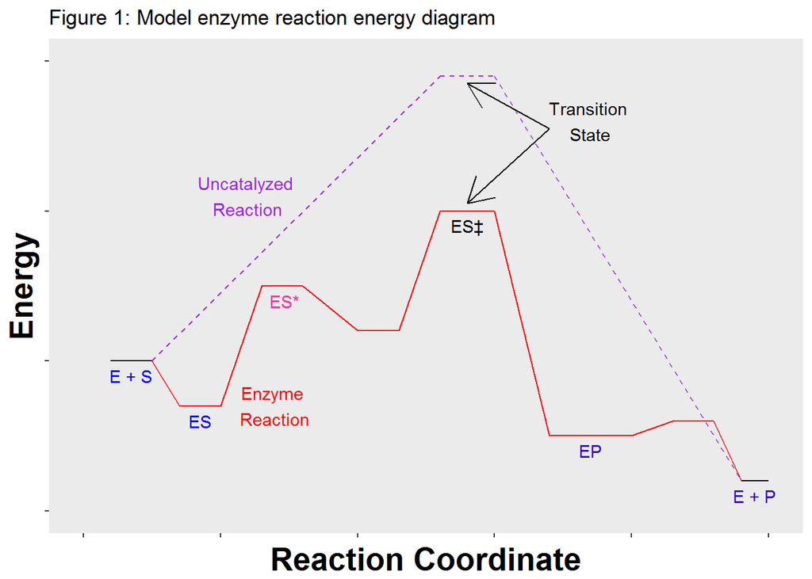

### Enzyme Activity

If we could watch an individual enzyme work converting reactants (also called the substrates) into product, we would first see a collision occur between the enzyme and substrate reflecting the enzyme binding to the substrate. After binding, the enzyme might then undergo a conformational change or proceed straight to producing the products. All of these steps are part of the enzyme reaction. In Figure 1, a conformational change step is shown ES*. The steps marked ES and EP represent the enzyme bound to the substrate (ES) or product (EP). ES$^\ddagger$ represents the enzyme bound to the transition state. Notice that the energies required for these steps are less than the energy of the transition state. Thus while they are occuring, they are difficult to see in most measurements of enzyme activity and therefore appear “invisible”.

If we plotted our observations of the product and substrate over time, we might see a plot like in Figure 2.

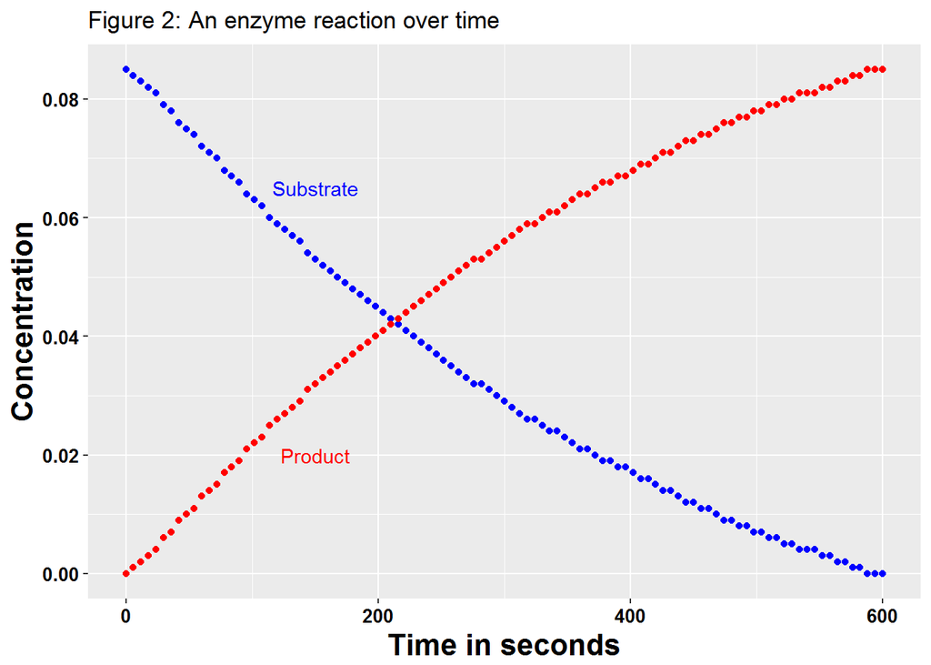

Notice how the amount of product formed (red) increases over time while the amount of substrate present (blue) decreases. These two processes are directly related so the data appear to mirror each other. As the experiment approaches the end, notice how the data begin to curve toward zero slope, indicating that the enzyme reaction is no longer in the **steady-state**. We will discuss the steady-state in more detail below. If we wanted to use the above plot to compare to an enzyme reactions performed in distinct conditions, it would be hard to simply use the amount of substrate lost or product formed at the endpoints. This is because we do not know what happened between starting the reaction and the measurement. Instead, we calculate a **rate** or the change in substrate/product over time. The rate of a reaction is directly related to the energy required to reach the transition state. Therefore we can infer aspects of the reaction chemistry from measuring the rate of the reaction. We will discuss how to determine the rate in more detail below. To summarize, enzymes increase the rate of the reaction by lowering the activation energy or energy required to reach the transition state. We can measure the change in reaction products or substrates over time to measure rates, which allow for comparison between experimental conditions or enzymes.

## Enzyme Kinetics

The field of kinetics is the study of the rates of reactions. In biochemistry, kinetics of enzyme reactions are studied to gain insight into the mechanism and regulation of an enzymes. The mechanism of an enzyme includes the order of substate binding and product release, the rate-limiting step(s), and the chemical processes that might occur. This latter aspect is often determined by measuring enzyme reaction rates under different conditions such as changing the solvent pH, the solvent ionic strength, or using inhibitors that look like potential chemical structures along the reaction pathway. The basic data that forms the foundation for much of our conclusions about enzyme mechanism is a **substrate saturation experiment**. In this experiment, the effect of substrate concentration on the rate is measured. From this type of experiment, we can determine how well a substrate binds to the enzyme and measure the magnitude of the rate-limiting step. A high quality kinetics experiment can reveal a lot about an enzyme, however care must be taken not only in the experimental setup but also the fitting of the data, which we will cover in more detail in the sections below.

### The Steady State

The **steady-state** is when the input and output of a reaction are balanced such that the concentrations of all the intermediates are not changing. If this sounds similar to chemical equilibrium, that is true. However, chemical equilibrium is a closed system, while a system in the steady-state has a constant influx of reactants and efflux of products. How does this apply to enzymes? For an enzyme, the pool substrate is the input, while the pool of product is the output. What are the intermediates? The intermediates refer to all the steps of the enzyme reaction. For the enzyme in Figure 1, this would be ES, ES*, ES$^\ddagger$, and EP. In the steady-state, the concentrations of enzyme at these intermediates steps would not be changing.

Practically, we *assume* an enzyme is in the steady-state when:

1. Less than 10% of the substrate has been converted into product
2. There is no inhibition of the enzyme by the product
3. The concentration of enzyme is very small compared to the concentration substrate.

Rates from enzyme reactions that are not in the steady-state can be studied and can produce interesting findings however there are more caveats to the intepretations of the data.

## Making a saturation plot

The first step in making a saturation plot is to collect the data. Typically, the amount of product formed (or susbtrate consumed) over time is measured at several concentrations of substrate. At minimum, 6 concentrations of substrate should be used to form the curve and span a minimum of a 10-fold substrate concentration range (i.e. 10 to 100). However, with more data and a wider span of substrate concentrations, the better the data. Remember to be in the steady-state, the concentration of enzyme should be much smaller than the lower substrate concentration.

In addition to the conditions above, data should be collected such that there is no product inhibition and less than 10% of the substrate has been consumed. I always err on the side of collecting as much data as feasible as it is easier to remove data that falls outside these requirements than to hope you are in the steady-state. A good indicator that you are within the steady-state is the amount of product formed is linear with time.

Below is a preview of a data set to be analyzed.

| Time | Bkgd | Substrate concentrations in micromolar 10 | Substrate concentrations in micromolar 30 | Substrate concentrations in micromolar 60 | Substrate concentrations in micromolar 90 | Substrate concentrations in micromolar 100 | Substrate concentrations in micromolar 200 | Substrate concentrations in micromolar 500 | Substrate concentrations in micromolar 1000 | Substrate concentrations in micromolar 1500 | Substrate concentrations in micromolar 2000 | Substrate concentrations in micromolar 3000 | Substrate concentrations in micromolar 4000 | Substrate concentrations in micromolar 5000 |
| --- | --- | --- | --- | --- | --- | --- | --- | --- | --- | --- | --- | --- | --- | --- |
| 0 | 0.208 | 0.208 | 0.207 | 0.198 | 0.209 | 0.200 | 0.216 | 0.205 | 0.239 | 0.209 | 0.237 | 0.236 | 0.273 | 0.467 |
| 6 | 0.208 | 0.209 | 0.207 | 0.199 | 0.210 | 0.201 | 0.219 | 0.207 | 0.244 | 0.213 | 0.242 | 0.240 | 0.278 | 0.470 |
| 12 | 0.209 | 0.209 | 0.208 | 0.199 | 0.212 | 0.202 | 0.222 | 0.209 | 0.249 | 0.217 | 0.247 | 0.245 | 0.283 | 0.473 |
| 18 | 0.208 | 0.209 | 0.209 | 0.200 | 0.213 | 0.203 | 0.225 | 0.211 | 0.254 | 0.221 | 0.252 | 0.250 | 0.287 | 0.477 |
| 24 | 0.209 | 0.209 | 0.209 | 0.200 | 0.214 | 0.204 | 0.228 | 0.213 | 0.258 | 0.225 | 0.257 | 0.254 | 0.291 | 0.481 |
| 30 | 0.209 | 0.209 | 0.210 | 0.201 | 0.216 | 0.206 | 0.231 | 0.216 | 0.263 | 0.229 | 0.261 | 0.259 | 0.296 | 0.484 |

Figure 3 shows the data from the table as a scatter plot with each substrate concentration in a distinct color.

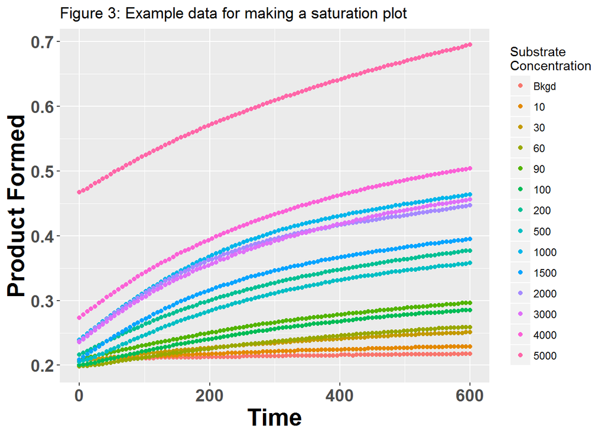

Notice that the data spans a 500-fold range of substrate concentrations and that data are collected over a 10 minute span, even though only the first ~60 seconds would be sufficient. The plateau that is observed is indicative of product inhibition or enzyme denaturation or lack of substrate or other factors. Also, there is a **control reaction** that measures the **background rate**. Most chemical reactions will occur at some rate in the absence of an enzyme and we need to anknowledge that this second reaction is occur in the enzyme reactions tubes. Even though this reaction is slow, we need to show that the enzyme reaction is occur above this rate. For fitting we will measure this value and then subtract it from the apparent enzyme rate to calculate the true enzyme reaction rate. Once we have substracted the background reaction, we can then calculate the reaction rates.

### Fitting data to calculate the initial velocity

| Concentration (uM) | Rate (Abs/sec) |
| --- | --- |
| 10 | 0.0000209 |
| 30 | 0.0000580 |
| 60 | 0.0000881 |
| 90 | 0.0001295 |
| 100 | 0.0001268 |
| 200 | 0.0002424 |
| 500 | 0.0002370 |
| 1000 | 0.0003350 |
| 1500 | 0.0002724 |
| 2000 | 0.0003020 |
| 3000 | 0.0003297 |
| 4000 | 0.0003512 |
| 5000 | 0.0003549 |

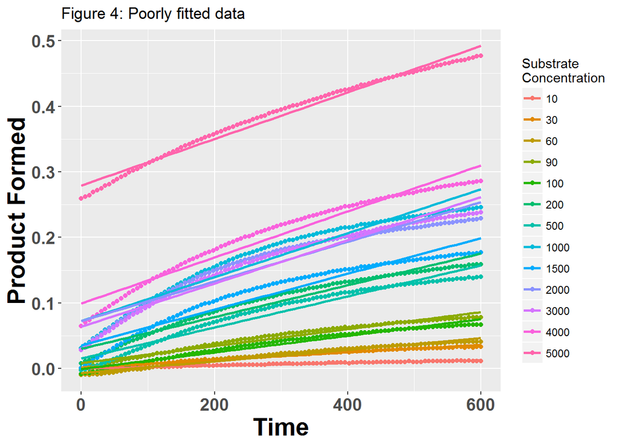

To improve the fit, we should recalculate the rates with only the first 15 or so observations. The rate we measure is often called the **initial rate** or **initial velocity** and is what should be used for fitting under the steady-state assumption.

| Concentration (uM) | Bad Rates (Abs/sec) | Good rates (Abs/sec) |
| --- | --- | --- |
| 10 | 0.0000209 | 0.0000106 |
| 30 | 0.0000580 | 0.0000813 |
| 60 | 0.0000881 | 0.0001127 |
| 90 | 0.0001295 | 0.0001883 |
| 100 | 0.0001268 | 0.0001904 |
| 200 | 0.0002424 | 0.0004375 |
| 500 | 0.0002370 | 0.0003938 |
| 1000 | 0.0003350 | 0.0007075 |
| 1500 | 0.0002724 | 0.0005997 |
| 2000 | 0.0003020 | 0.0007067 |
| 3000 | 0.0003297 | 0.0006712 |
| 4000 | 0.0003512 | 0.0006716 |
| 5000 | 0.0003549 | 0.0005494 |

When we compare the data, overall the initial rates are faster than the total rate. This should make sense as we are eliminating data which includes inhibited enzyme or decreased amount of substrate, both of which would decrease the enzyme rate.

A quick look at the plot shows the linear fits match the data well, suggesting we have calculated accurate initial rates.

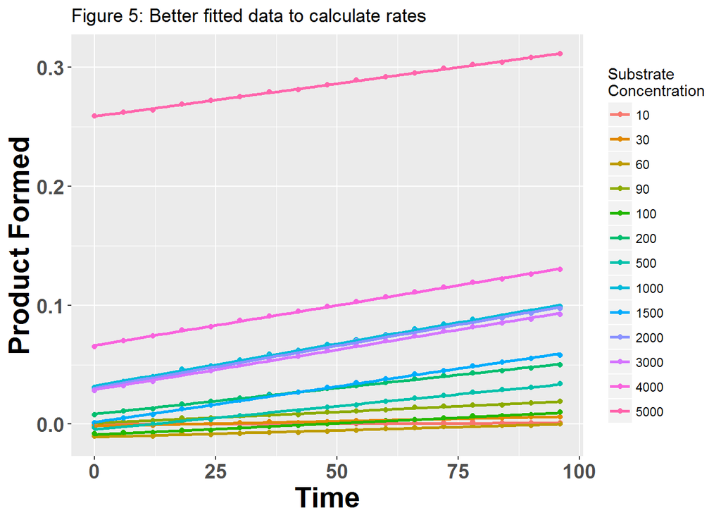

### Plotting the data as a saturation curve

Now that we have initial rates, we can plot the effect of substrate concentration on the rate. The data re shown in Figure 6. (**Note:** that I converted the units of the rate to milli absorbance units for easier plotting.)

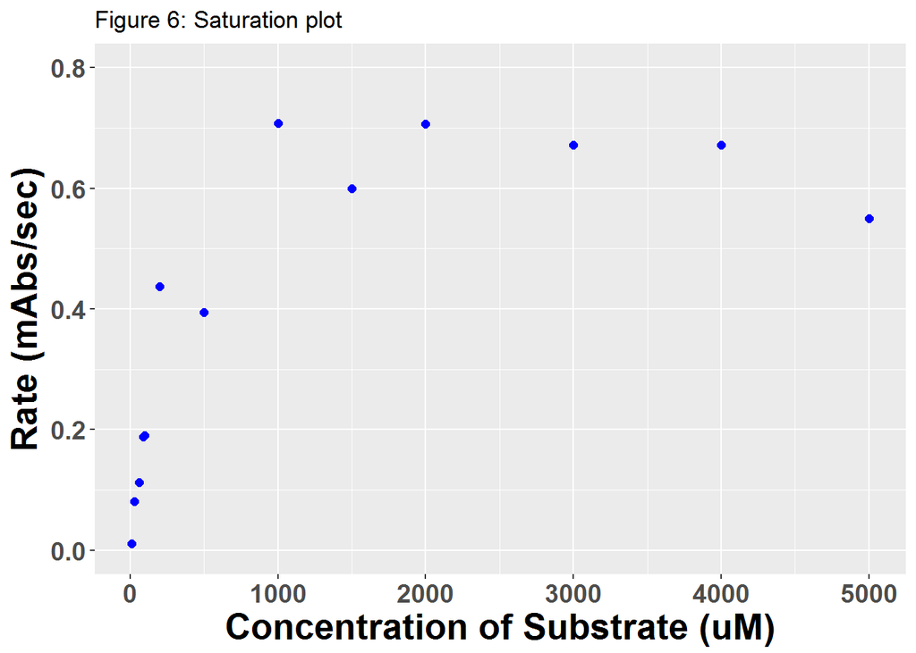

Using these data, we can begin to calculate the kinetic values to describe how well the enzyme binds to substrate and how fast the enzyme catalyzes the reaction.

### Estimating kinetic values from a saturation plot

From the data in Figure 6, we can estimate the kinetic parameters **V<sub>max</sub>** and **K<sub>M</sub>**. The **V<sub>max</sub>** value is the maximum rate of the enzyme reaction under the given conditions and is the rate of the slowest step in the enzyme reaction. The **K<sub>M</sub>** is the substrate concentration that results in $1/2$ V<sub>max</sub>. K<sub>M</sub> can be thought of as how well the enzyme binds to the substrate. A lower K<sub>M</sub> means the enzyme binds to the substrate better or with high **affinity**.

Figure 7 shows the saturation plot with lines to estimate V<sub>max</sub> and K<sub>M</sub>. I have predicted V<sub>max</sub> to be 0.75 mAbs/sec (or 0.00075 Abs/sec) while K<sub>M</sub> is approximately 300 uM.

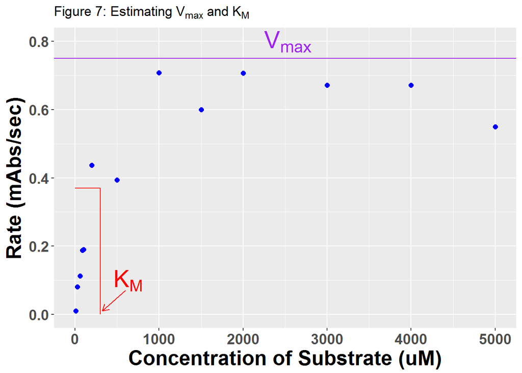

Notice that V<sub>max</sub> is not the fastest rate measured in the experiment but some value that is slightly higher. This is because V<sub>max</sub> is a value that can be *approached* but never *reached*, as to reach V<sub>max</sub> requires infinite concentration of substrate which is difficult to attain in an experiment.

## Fitting the data to calculate kinetic constants

### Direct fitting of the data

Given that the data saturates and covers a wide range of substrate concentrations, the estimates of the kinetic values can be improved upon by fitting the data to the **Michaelis-Menten equation**.

$$rate = (V_{max}*[Substrate])/(K_{M} + [Substrate])$$

While you are solving for two parameters in the fit, most modern spreadsheet software or fitting programs can handle this problem (See below for details). The table below shows the fitted values for V<sub>max</sub> and K<sub>M</sub> and these values are close to our estimated values in the figure above.

| term | estimate | std.error |
| --- | --- | --- |
| K | 2.100e+02 | 5.61e+01 |
| V | 7.021e-04 | 4.12e-05 |

As we have seen however, sometimes the numbers for a fit are misleading and direct inspection of the fit with the data is always necessary.

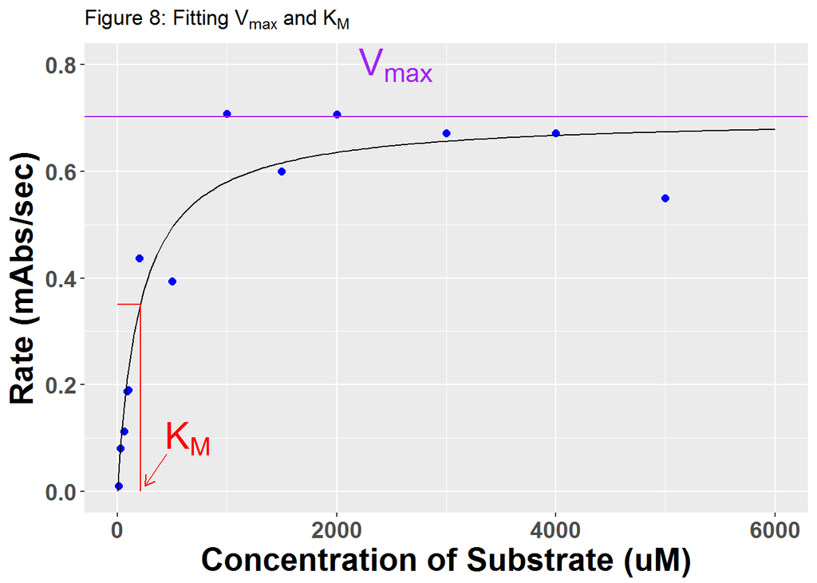

Figure 8 shows that the data fit is a good fit to the data. We could further support the quality of fit by showing the **residuals** plot. The residual is the distance between the fitted value and the actual value. Trends in the residual plot can show systematic problems with the fitting equation or the experiment (Figure 9).

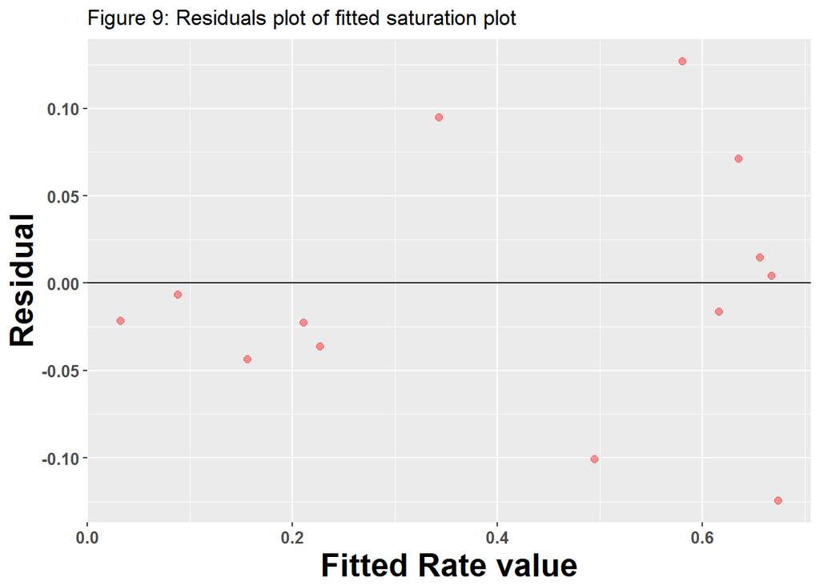

The residuals show some random scatter around zero which is good, however there is a trend for the data at higher concentrations to be further from the fit, which we see in Figure 8 as well. These deviations are not ideal and indicate some problems with the data. This is where repeated experiments will help by reducing the error and uncertainty in the data. *A single experiment can give you ideas, while multiple experiments provide evidence.*

### Using a Lineweaver-Burk fit

A popular way to represent saturation data before the advent of computers was the double reciprocal or Lineweaver-Burk plot (Figure 10). This type of fit has the advantage of being easy to fit since the data form a straight line. Moreover, the kinetic values are easy to calculate. The y-intercept is equal to 1/V<sub>max</sub>, while the x-intercept is equal to -1/K<sub>M</sub>. However, performing a non-linear transformation of the data it is fraught with issues in fitting and inaccuracies as we shall see. This is not to say that the fit is not useful for on the fly types of estimations, but it should not be used for quantitative fitting.

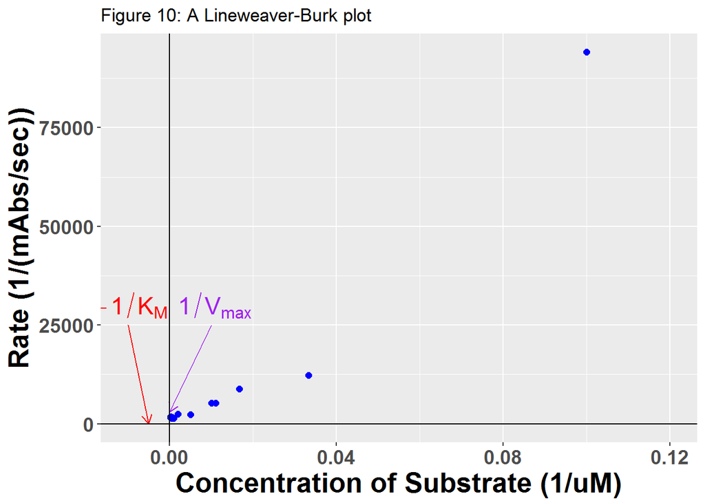

Figure 11 shows the Lineweaver-Burk plot with the best fit straight line in blue and the transformed fit from Figure 8 in red. The trendline fit overweights the single point at x = 0.1 resultiing in impossible values for V<sub>max</sub> and K<sub>M</sub>. Even removal of this single data point would produce issues. However, this fit is worth doing when only an estimate is needed and access to a computer might be limited.

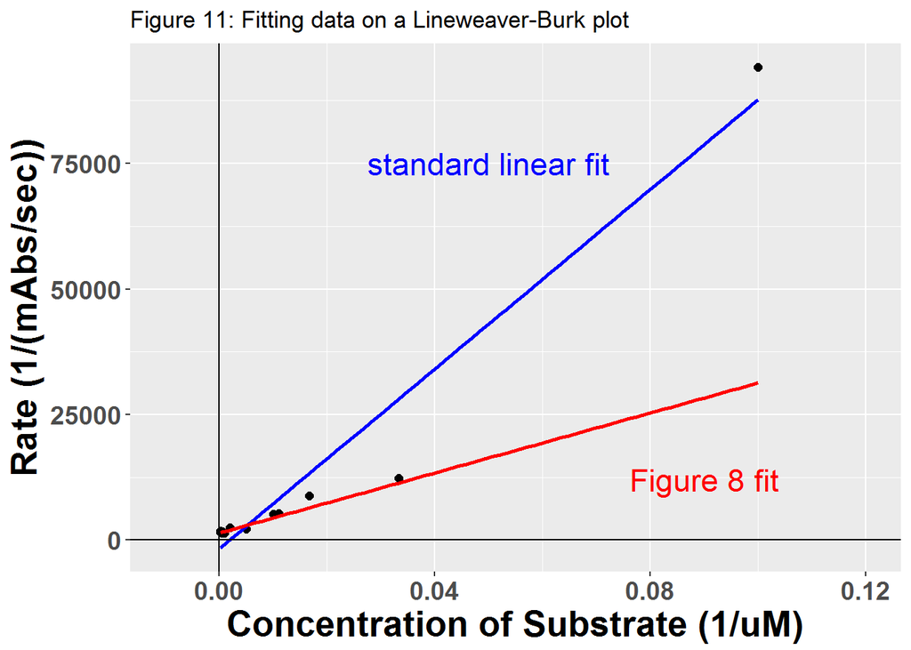

### How to fit using Excel/Google Sheets to fit the data

Throughout this guide we have described how to create data and shown how the data can be fit, but not addressed the details of fitting the data. I have used standard R in this guide to do the fitting, statistics, and visualizing of the data. Fitting a saturation plot in R is straight-forward once you have the data as has been shown [here](https://rpubs.com/RomanL/6752) and [here](http://rforbiochemists.blogspot.com/2015/05/plotting-and-fitting-enzymology-data.html).

However, I know most students are more familiar with Microsoft Excel or the web-based Google Sheets. Both are good to do fitting of data, however it takes a bit of work. The [protocol](https://www.nature.com/articles/nprot.2009.182) by Kemmer and Keller is a good resource with step by step instructions.

These steps are outlined below:

1. Enable Solver in Excel via the Options>Add-ins menus In Sheets, download the Risk Solver and Solver add-ons.
2. Import data with concentration in column A and the rate in column B.
3. Designate a cell as V<sub>max</sub> and another cell as K<sub>M</sub>. Enter estimates of V<sub>max</sub> and K<sub>M</sub> in the cells. Designate a third cell as SSR.
4. In column C, type =(V<sub>max</sub> * [S])/(K<sub>M</sub> + [S]), where [S] points to the first data cell in column A, and V<sub>max</sub> and K<sub>M</sub> point to the cells designated in step 3.
5. Propagate this equation down the entire set of concentrations. If you defined cells names or use the $ lock symbol in the first equation, this is straightforward to do.
6. In column D, calculate the squared residual by substracting the rate calculated in column C from the rate in column B and squaring the difference. Do this for each rate measurement.
7. In the cell designated as SSR, sum the numbers in column D.
8. *Finally*, you can fit the data. Go to Data>Solver in Excel or Add-ons Solver in Sheets. Set the Objective as SSR, To as Min, by changing the numbers in the V<sub>max</sub> and K<sub>M</sub> cells. Click Ok to start the solving!
9. The values in V<sub>max</sub> and K<sub>M</sub> cells should have changed to fit the data, the rates in column C should be near the measured rates in column B, the SSR value should be smaller.
10. Plot your data on a scatter plot with your measured rates as dots and your theoretical data as a line to see the fit.

Determining error is not easy in Excel or Sheets, however Kemmer and Keller provide a way to estimate confidence intervals using critical Chi-squared values. To make it easier, I would encourage learning how to fit using R if you do not like black boxes or a fitting program if you do like black boxes.

## Where next?

### k<sub>cat</sub> and k<sub>cat</sub>/K<sub>M</sub>

I defined V<sub>max</sub> earlier as the maximum rate under a given set of conditions, which includes the concentration of enyzme in the experiment. To make comparison at enzyme concentration, divide V<sub>max</sub> by the enzyme concentration such that the units reduce to time<sup>-1</sup>. This value, called **k<sub>cat</sub>** has the units of a first-order rate and is the number of times that the enzyme catalyzes the reaction per unit of time (typically sec).

Comparing kinetics between enzymes or substrates is difficult as well. Is an enzyme with a V<sub>max</sub> of 100 and a K<sub>M</sub> of 10 better than an enzyme with a V<sub>max</sub> of 75 and a K<sub>M</sub> of 5? It is hard to tell. To reduce this issue, enzyme reactions are compared using the value **k<sub>cat</sub>/K<sub>M</sub>**. Think of this as the catalytic efficiency of the enzyme. This constant incorporates both the rate of the reaction and how well the substrate binds to the enzyme. We can calculate k<sub>cat</sub>/K<sub>M</sub> by dividing our individual k<sub>cat</sub> and K<sub>M</sub> values or by calculating the slope of the line of all the substrate concentrations below K<sub>M</sub> in a saturation plot. These data should fit to a linear model well and the slope is equal to k<sub>cat</sub>/K<sub>M</sub>. Data comparing substrates with k<sub>cat</sub>/K<sub>M</sub> is shown [here](https://www.ncbi.nlm.nih.gov/pmc/articles/PMC1994252/).

### Enzymes with two or more substrates

Many enzymes use multiple substrates, so the equations get to be more complex. For instance look at the Michaelis-Menten equation for an enzyme with two substrates A and B:

$$rate = (V_{max}*[A]*[B])/(K_{M,A}*[B] + K_{M,B}*[A] + K_{i,A}*K_{M,B} + [A][B])$$

While this is not hard to fit to data, the fitting can be made simpler by designing the experiment to resemble measuring the kinetics of an eyzme working on a single substrate. For example, the concentration of substrate B would be saturating while we would vary the concentration of substrate A. Then switch the roles of the substrate to determine the kinetics for substrate B.

In a more advanced experimental setup, we can determine the kinetic mechanism of a multisubstrate enzyme by warying both substrates by performing and looking at how the kinetic values are intertwined. An example of using saturation plots to determine enzyme mechanism is shown [here](https://www.ncbi.nlm.nih.gov/pmc/articles/PMC2752042/). However, we will leave the details of this experiment for another guide.

### Reaction conditions

In addition to multisubstrate enzymes, changing the conditions of hte reaction such as temperature, pH or solvent viscosity and observing the effects on V<sub>max</sub> and K<sub>M</sub> is also useful. Changing the pH can reveal if the chemistry of the enzyme requires H<sup>+</sup> to be transferred ([example](https://www.ncbi.nlm.nih.gov/pmc/articles/PMC2752042/)). Changing solvent viscosity can indicate if structural changes in the enzyme or binding/dissociation steps are rate-limiting ([example](https://www.ncbi.nlm.nih.gov/pmc/articles/PMC2519119/)).

Finally, we can analyze the binding of inhibitors which can help with diagnosing a mechanism and be crucial in the development of therapeutics. Saturation experiments are performed in the presence and absence of the inhibitor and the changes in the kinetic constants can be used to calculate inhibitor affinity and mechanism ([example](https://www.ncbi.nlm.nih.gov/pmc/articles/PMC4220450/) and [example](https://www.ncbi.nlm.nih.gov/pmc/articles/PMC2752042/)).

Finally, not all enzymes bind to substrates in a simple way, some use cooperative binding, meaning the binding of one substrate influences the binding of further substrates to the enzymes. This behavior is called **cooperativity** and is seen mostly in enzymes that form large complexes ([example](https://www.ncbi.nlm.nih.gov/pmc/articles/PMC5717748/)).

Thus, from performing variations of the basic substrate saturation experiment scientists can describe enzyme chemistry and gain insight into molecules that could develop into therapeutics.

## Further Reading

[Michaelis-Menten kinetics](https://www.ncbi.nlm.nih.gov/books/NBK22430/)

[Lineweaver-Burk plots](https://www.ncbi.nlm.nih.gov/books/NBK22557/)

[Fitting Enzymology Data in R](http://rforbiochemists.blogspot.com/2015/05/plotting-and-fitting-enzymology-data.html)

[Michaelis-Menten in R](https://rpubs.com/RomanL/6752)

## Acknowledgements

I thank former student Kadir Ozcan who in the course of his research with me generated the enzyme data used throughout this document. I wish to acknowledge the work of Paul Brennan and his [R for Biochemists](http://rforbiochemists.blogspot.com/) blog which showed me how I could move to using R in my own research and teaching in many different ways.